# Entregable_Estadistica

Fermin Leal Payá & Rafael Vallejo Antich

January 3, 2018

## Entregable Estadística

Este documento es el entregable hecho por Fermín Leal Payá y Rafael Vallejo Antich para la evaluación del ejercicio práctico de estadística.

## Cambio de formato de los ficheros

Para que nuestro scrip de R pueda tratar los datos de forma correcta hemos cambiado el formato de los ficheros mediante un fichero bash. Este fichero (jaenclean.sh) se ejecuta en la misma carpeta donde se encuentran los datos y nos devolverá dos nuevos datasets con el formato correcto.

Para ejecutar el archivo nos movemos al directorio donde tenemos los datos en nuestro caso ./Datos y ejecutamos “bash jaenclean.sh” el cual nos devolverá dos archivos.

- JaenIndicadores-utf8.txt
- Andalucia-utf8.txt

# Ejercicios

## 1. Cálculo de nuevas variables, recodificación y filtrado

### 1. Importar el fichero JaenIndicadores.txt y denominar a la hoja de datos (data frame) Datos.Jaen

```r
Datos.Jaen <- read.table('./Datos/JaenIndicadores-utf8.txt',sep="\t", header=TRUE, encoding  ="UTF-8")
#Limpiar datos faltantes
Datos.Jaen <- Datos.Jaen[!Datos.Jaen$poblacion == "..", ]
options(warn=-1)
#Cambiar comas por puntos para poder calcular más tarde
Datos.Jaen$residuoscant <- gsub("\\,", ".", Datos.Jaen$residuoscant)
#Cambiar a numerico o doble las variables para los calculos
Datos.Jaen$poblacion <- (as.numeric(as.character(Datos.Jaen$poblacion)))
Datos.Jaen$consumoelec <- (as.numeric(as.character(Datos.Jaen$consumoelec)))
Datos.Jaen$consumoaguainv <- (as.numeric(as.character(Datos.Jaen$consumoaguainv)))
Datos.Jaen$consumoaguaver <- (as.numeric(as.character(Datos.Jaen$consumoaguaver)))
Datos.Jaen$residuoscant <- (as.double(Datos.Jaen$residuoscant))
```

### 2. Recodificar la variable Poblacion en una variable cualitativa tipo factor llamada Tamaño con tres categorías:

- Si la población es inferior a 2000 habitantes, Tamaño será “Pequeño”.
- Si la población está entre 2000 y 4500 habitantes, Tamaño será “Mediano”
- Si la población es superior a 4500 habitantes, Tamaño será “Grande”.

```r
Datos.Jaen$poblacioncat[Datos.Jaen$poblacion<= 2000] <- "Pequeño"

Datos.Jaen$poblacioncat[Datos.Jaen$poblacion> 2000 & (as.numeric(as.character(Datos.Jaen$poblacion)))< 4500] <- "Mediano"

Datos.Jaen$poblacioncat[Datos.Jaen$poblacion>= 4500] <- "Grande"

Datos.Jaen$poblacioncat <- as.factor(Datos.Jaen$poblacioncat)

#Datos.Jaen$poblacion <- Datos.Jaen$poblacioncat

#Datos.Jaen<-Datos.Jaen[1:8]

options(warn=0)
```

### 3. Calcular los siguientes promedios que se especifican a continuación y añadirlos como nuevas variables al fichero Datos.Jaen obtenidas a partir de las variables existentes:

- Variable elec.hab que contendrá el consumo de energía eléctrica por habitante, obtenida como Consumo.de.energia.electrica/Poblacion
- Variable agua.hab que contendrá el consumo medio de agua por habitante y día, obtenida como (Consumo.de.agua..Invierno + Consumo.de.agua..V erano)/Poblacion
- Variable res.hab que contendrá los residuos sólidos urbanos por habitante, obtenida como Residuos.solidos.urbanos..Cantidad/Poblacion

```r
Datos.Jaen$elec.hab <- Datos.Jaen$consumoelec/Datos.Jaen$poblacion
Datos.Jaen$agua.hab <- (Datos.Jaen$consumoaguainv+Datos.Jaen$consumoaguaver)/Datos.Jaen$poblacion
Datos.Jaen$res.hab <- Datos.Jaen$residuoscant/Datos.Jaen$poblacion
```

### 4. Crear una nueva hoja de datos con todas las variables que contiene actualmente el data frame Datos.Jaen, pero referida sólo a los municipios de tamaño mediano y denominarla Datos.Jaen.Medianos

```r
Datos.Jaen.Medianos <- Datos.Jaen[Datos.Jaen$poblacioncat == 'Mediano',]
```

### 5. Guardar la hoja de datos Datos.Jaen con las nuevas variables creadas en los apartados anteriores y la hoja que contiene los datos de las poblaciones medianas (Datos.Jaen.Medianos) en un archivo de datos de R y llamadlo JaenIndicadores.RData

```r
save(Datos.Jaen, Datos.Jaen.Medianos, file = "./Datos/JaenIndicadores.RData")
```

## 2. Análisis Estadístico Descriptivo de Datos

### 1. Importar el fichero Andalucia.txt y denominar a la hoja de datos (data frame) Datos.Andalucia. Comprobar si en el archivo .txt hay datos faltantes y cómo están codificados.

```r
Datos.Andalucia <-  read.table('./Datos/Andalucia-utf8.txt',sep="\t", header=TRUE, encoding  ="UTF-8")
Datos.Andalucia[Datos.Andalucia$Renta.familiar.por.habitante.2003 == "..","Renta.familiar.por.habitante.2003"] <- NA
```

### 2. A partir de la variable código INE, construir una variable tipo factor que distinga la provincia de pertenencia de cada municipio, denominarla “Provincia” y añadirla al data frame.

```r
Datos.fProv = c("Almeria","Cadiz","Cordoba","Granada","Huelva","Jaen","Malaga","Sevilla")

Datos.Andalucia$IdINE <- substr(Datos.Andalucia$Codigo.INE,1,nchar(Datos.Andalucia$Codigo.INE)-3)

Datos.Andalucia$Provincia[Datos.Andalucia$IdINE == 4] <- Datos.fProv[1]
Datos.Andalucia$Provincia[Datos.Andalucia$IdINE == 11] <- Datos.fProv[2]
Datos.Andalucia$Provincia[Datos.Andalucia$IdINE == 14] <- Datos.fProv[3]
Datos.Andalucia$Provincia[Datos.Andalucia$IdINE == 18] <- Datos.fProv[4]
Datos.Andalucia$Provincia[Datos.Andalucia$IdINE == 21] <- Datos.fProv[5]
Datos.Andalucia$Provincia[Datos.Andalucia$IdINE == 23] <- Datos.fProv[6]
Datos.Andalucia$Provincia[Datos.Andalucia$IdINE == 29] <- Datos.fProv[7]
Datos.Andalucia$Provincia[Datos.Andalucia$IdINE == 41] <- Datos.fProv[8]

#Obtener la distribución de frecuencias absolutas y relativas, un diagrama de barras con las frecuencias absolutas y un
#diagrama de sectores con las frecuencias relativas en porcentajes de esta variable tipo factor.
#¿Qué provincia tiene más municipios? ¿Cuál tiene menos? ¿Qué porcentaje representa en cada caso?

Datos.Andalucia$Provincia <- as.factor(Datos.Andalucia$Provincia)
print('Frecuencia absoluta: ')
```

```
## [1] "Frecuencia absoluta: "
```

```r
frec.abs <-table(Datos.Andalucia$Provincia)
frec.abs
```

```
##
## Almeria   Cadiz Cordoba Granada  Huelva    Jaen  Malaga Sevilla
##     102      44      75     168      79      97     100     105
```

```r
print('Frecuencia relativa')
```

```
## [1] "Frecuencia relativa"
```

```r
frec.rel <-table(Datos.Andalucia$Provincia)/sum(table(Datos.Andalucia$Provincia))*100
frec.rel
```

```
##
##   Almeria     Cadiz   Cordoba   Granada    Huelva      Jaen    Malaga
## 13.246753  5.714286  9.740260 21.818182 10.259740 12.597403 12.987013
##   Sevilla
## 13.636364
```

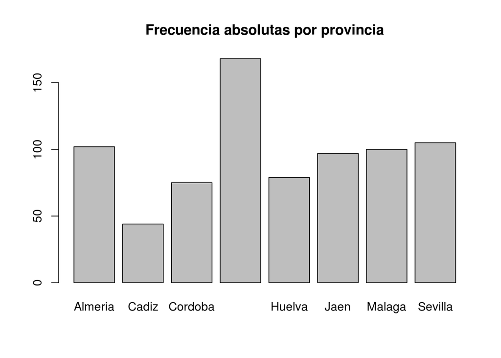

```r
#Bar plot frecuencias absolutas
barplot(frec.abs, main="Frecuencia absolutas por provincia")
```

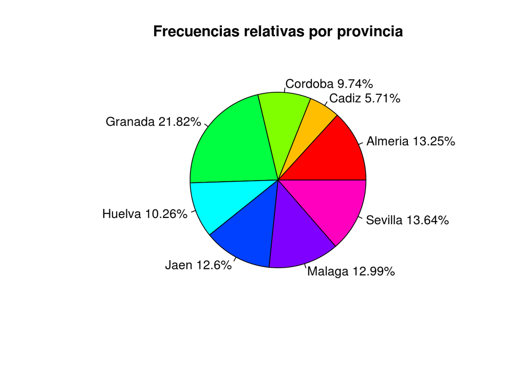

```r
#Pie plot frecuencias relativas
slices <- frec.rel
lbls <- rownames(frec.rel)
pct <- round(slices/sum(slices)*100,2)
lbls <- paste(lbls, pct) # add percents to labels
lbls <- paste(lbls,"%",sep="") # ad % to labels
pie(slices,labels = lbls, col=rainbow(length(lbls)), main="Frecuencias relativas por provincia")
```

### 3. Obtener un resumen descriptivo de la variable tasa de actividad de 2001 que incluya parámetros de posición, dispersión, asimetría y curtosis, histograma y diagrama de caja. En función de este resumen, contestar a las siguientes preguntas:

```r
#Vamos a arreglar la columna para los calculos
#Cambiar comas por puntos. Si lo dejaramos como está la conversión a otro tipo de dato sería errónea.

Datos.Andalucia$Tasa.actividad.2001 <- gsub("\\,", ".", Datos.Andalucia$Tasa.actividad.2001)
Datos.Andalucia$Tasa.actividad.2001 <- (as.double(Datos.Andalucia$Tasa.actividad.2001))

#####################Parámetros de posición#####################

summary(Datos.Andalucia$Tasa.actividad.2001)
```

```
##    Min. 1st Qu.  Median    Mean 3rd Qu.    Max.
##   26.92   46.73   51.88   51.44   56.22   74.21
```

```r
#Media
media <- mean(Datos.Andalucia$Tasa.actividad.2001)
#Mediana
mediana <- median(Datos.Andalucia$Tasa.actividad.2001, na.rm=T)
# Percentil 5% y percentil 95%
percep <-quantile(Datos.Andalucia$Tasa.actividad.2001,probs=c(0.05,0.95),na.rm=TRUE)
## Mínimo
min.Tasa<-min(Datos.Andalucia$Tasa.actividad.2001, na.rm=T)
## Máximo
max.Tasa<-max(Datos.Andalucia$Tasa.actividad.2001, na.rm=T)
## Primer cuartil
q1.Tasa<-quantile(Datos.Andalucia$Tasa.actividad.2001, probs=0.25, na.rm=T)
## Tercer cuartil
q3.Tasa<-quantile(Datos.Andalucia$Tasa.actividad.2001, probs=0.75, na.rm=T)

#####################Parámetros de dispersión#####################
# Desviación típica
Des.tipica <- sd(Datos.Andalucia$Tasa.actividad.2001,na.rm=TRUE)
# Varianza
Varianza <- var(Datos.Andalucia$Tasa.actividad.2001,na.rm=TRUE)
# Recorrido intercuartílico
ri.Tasa<-q3.Tasa-q1.Tasa
# Rango
rango.Tasa<-max.Tasa-min.Tasa


#####################Parámetros de forma###################
#install.packages("e1071", dep = TRUE)
library(e1071)
coef_asimetria <- skewness(Datos.Andalucia$Tasa.actividad.2001,na.rm=TRUE)
print (coef_asimetria)
```

```
## [1] -0.09917887
```

```r
coef_curtosis <- kurtosis(Datos.Andalucia$Tasa.actividad.2001,na.rm=TRUE)
print (coef_curtosis)
```

```
## [1] 0.1241295
```

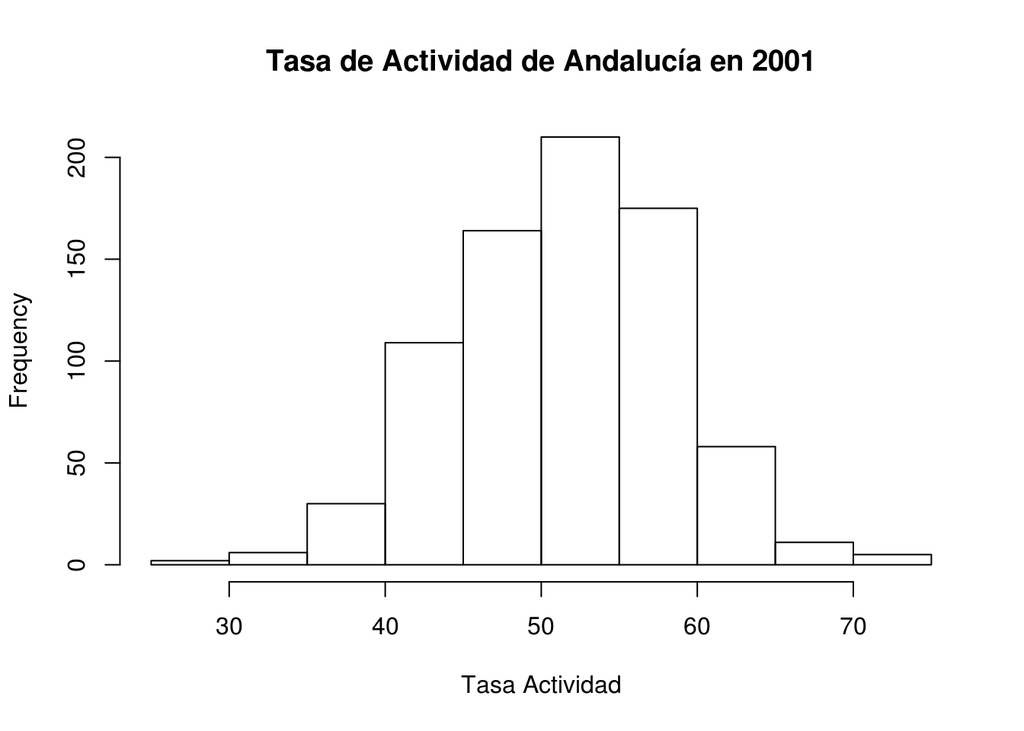

```r
#histograma
hist(Datos.Andalucia$Tasa.actividad.2001, main = "Tasa de Actividad de Andalucía en 2001", xlab="Tasa Actividad")
```

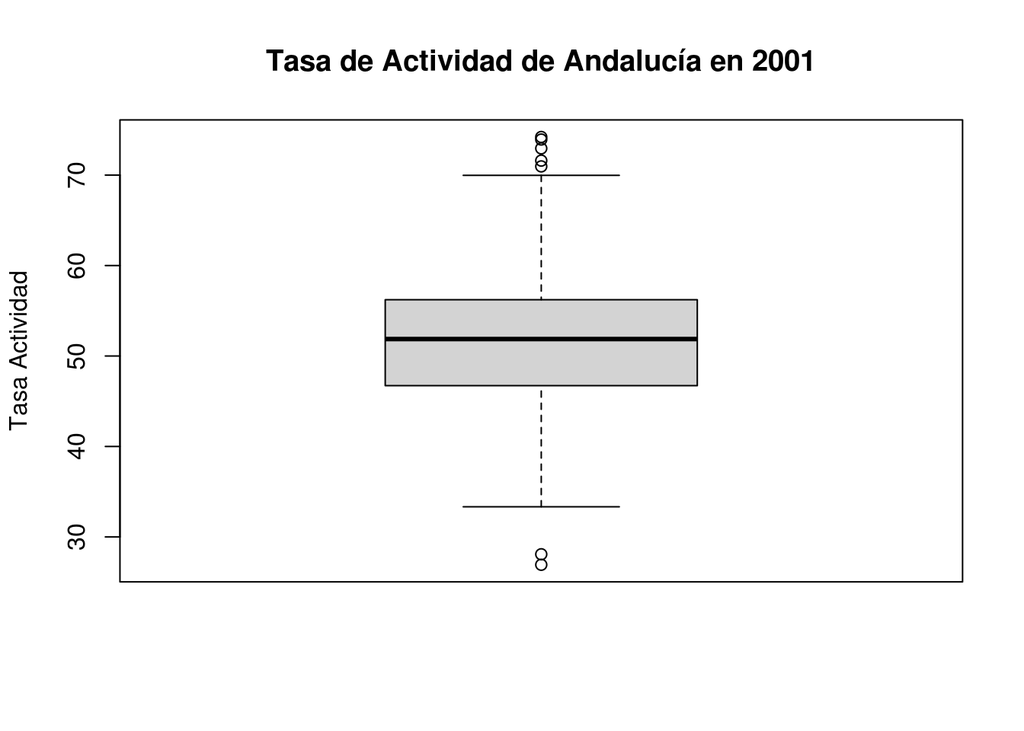

```r
#Diagrama de caja
boxplot(Datos.Andalucia$Tasa.actividad.2001, main = "Tasa de Actividad de Andalucía en 2001",
col = "lightgray", ylab="Tasa Actividad")
```

#### 3.1. ¿Cuál es la tasa media de actividad de los municipios andaluces? ¿Crees que este valor es adecuado para representar la Tasa de Actividad de los municipios andaluces durante 2001?

Valor medio = 51.44 Creemos que es un valor correcto ya que no tenemos outlayers muy grandes lo que hace que la media y la media estén muy cercanas

#### 3.2. ¿Cómo valoras la homogeneidad de los valores de la tasa de actividad en los municipios andaluces? ¿Qué parámetro elegirías para representar la dispersión de la Tasa de Actividad de 2001?

En el dataset analizado la tasa de actividad parece homogneo ya que los datos no presentan mucha desviación y el coeficiente de asimetría presenta un valor muy bajo.

Podemos elegir la desviación típica ya que es una medida de dispersión de las variables Des.tipica. Segun los valores que tenemos consideramos que el valor de desviación típica 6.98 es bastante bajo viendo que los valores estan entre 30 y 70

#### 3.3. ¿En ese sentido, qué municipios andaluces destacan significativamente del resto (como atípicos) por su alta tasa de actividad y por su baja tasa de actividad? ¿Se te ocurre alguna explicación al respecto?

```r
#which(Datos.Andalucia$Tasa.actividad.2001==min.Tasa)
outlier_values <- boxplot.stats(Datos.Andalucia$Tasa.actividad.2001)$out #vemos los outlayers
Datos.Andalucia$Municipio[which(Datos.Andalucia$Tasa.actividad.2001<=28.08)] #-- Benitagla    Lobras
```

```
## [1] Benitagla Lobras
## 770 Levels: Abla Abrucena Adamuz Adra Agrón ... Zurgena
```

```r
Datos.Andalucia$Municipio[which(Datos.Andalucia$Tasa.actividad.2001>=70.96)] #-- Vícar                Ejido (El)           Mojonera (La)        Alcalá del Valle     Castilleja de Guzmán)$out
```

```
## [1] Vícar                Ejido (El)           Mojonera (La)
## [4] Alcalá del Valle     Castilleja de Guzmán
## 770 Levels: Abla Abrucena Adamuz Adra Agrón ... Zurgena
```

En principio, no parece que los outliers se deban a datos anómalos o mal registrados, puesto que la tasa de actividad no deja de ser un valor razonable.

Para los municipios que poseen una tasa de actividad baja (Benitagla y Lobras) se ha observado que se trata de pueblos con muy poca población y una edad media bastante elevada. Lo cual explicaria una reducida tasa de actividad.

Por el contrario, los municipios que presentan una tasa de actividad alta (Vícar, Ejido (El), Mojonera (La), Alcalá del Valle y Castilleja de Guzmán) son municipios con una media de edad baja y de poblacion bastante elevada, lo cual explicaria una tasa de actividad mas alta.

#### 3.4. ¿Cómo valoras la simetría de la distribución de frecuencia?

Es bastante simétrica ya que el coefieciente de asimetria es cercano a 0.

### 4. Obtener un gráfico de caja de la Tasa de actividad en 2001 en función de la provincia y describe brevemente la información que contienen los datos a partir del gráfico.

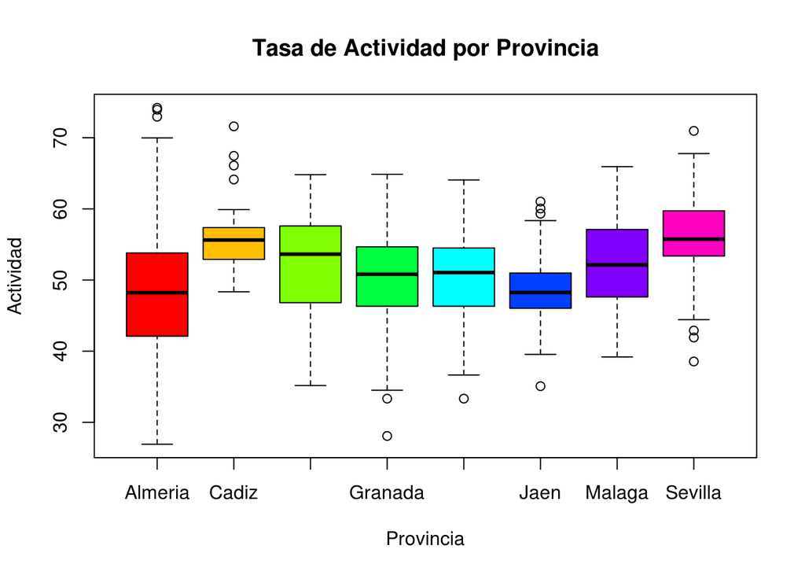

```r
boxplot(formula = Datos.Andalucia$Tasa.actividad.2001 ~ Datos.Andalucia$Provincia,
        main = "Tasa de Actividad por Provincia",
        xlab = "Provincia",
        ylab = "Actividad",
col = rainbow(8))
```

Además, si bien es cierto que la mayoría de provincias presentan una varianza similar, hay casos especiales como puede ser Almería (que muestra una alta dispersión) y Cádiz (que presenta una varianza muy baja, lo que hace que la mayoría de valores se sitúen próximos a su mediana).

Por otra parte, a pesar de que tanto Cádiz como Sevilla presentan ligeras asimetrías negativa y positiva, respectivamente, no se trata de asimetrías que puedan serconsideradas significativas. En conclusión podemos afirmar que la tasa de actividad de todas las provincias presentan un coeficiente de asimetría prácticamente nulo.

Por último, podemos observar como el conjunto de outliers depende de cada provincia. Habiendo provincias que no presentan datos anómalos (Córdoba o Málaga), mientras que otras representan varios outliers (Cádiz y Sevilla, por ejemplo).

## 3. DISTRIBUCIONES DE PROBABILIDAD

### 1. Consideremos una variable aleatoria que sigue una distribución B (15, 0.33). Se pide:

#### 1.1. ¿Qué valor de la variable deja por debajo de sí el 75% de la probabilidad?

```r
qbinom(0.75, 15, 0.33)
```

```
## [1] 6
```

El valor es 6

#### 1.2. Calcular el percentil 95% de la distribución.

```r
qbinom(0.95, 15, 0.33)
```

```
## [1] 8
```

El valor es 8

#### 1.3. Obtener una muestra de tamaño 1000 de esta distribución, representarla gráficamente las frecuencias observadas de cada valor de la distribución mediante un diagrama de barras y comparar éste con las frecuencias esperadas según el modelo que genera los datos.

```r
#Generamos las muestras
muestra_binomial <- rbinom(1000, 15, 0.33)

#Comprobación de datos
summary(muestra_binomial)
```

```
##    Min. 1st Qu.  Median    Mean 3rd Qu.    Max.
##   0.000   4.000   5.000   4.994   6.000  10.000
```

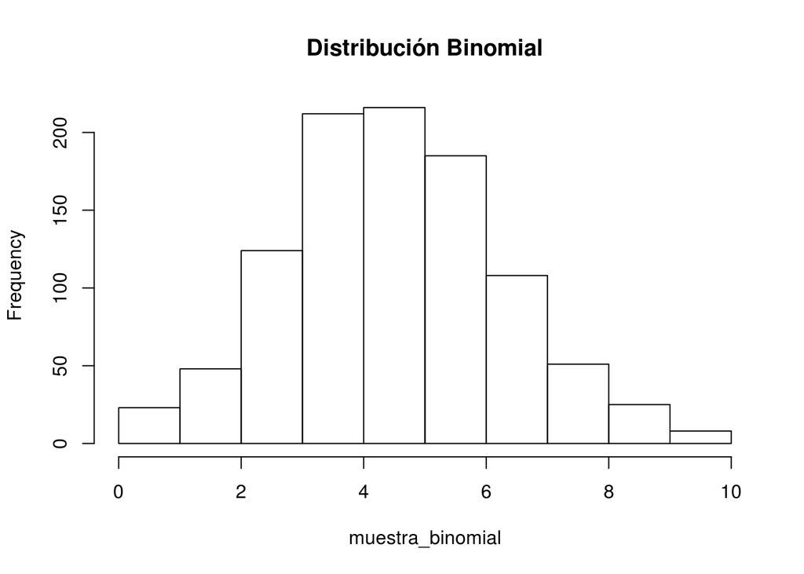

```r
#Histograma de la muestra binomial generada
hist(muestra_binomial, main="Distribución Binomial")
```

A la vista del histograma con las frecuencias obtenidas, vemos que los resultados se ajustan al modelo esperado:

Como ya hemos observado con el comando ‘summary’ la mediana se encuentra en el valor 5, mientras que los C1 y C3 se sitúan en los valores 4 y 6, respectivamente.

Además, a la vista de la gráifca vemos que coincide con los valores obtenidos en los puntos 1.1 y 1.2. Ya que el valor 6 intuimos que puede dejar a su izquierda el 75% de los datos, mientras que el valor 8 abarca el 95% de los mismos.

### 2. Consideremos una variable aleatoria W con distribución N (250, 13). Se pide:

#### 2.1. P [240 < W ≤ 245.5]

```r
#P(240 < W < 245.5) = F(245.5) - F(240)
pnorm(245.5, 250, 13) - pnorm(240, 250, 13) #0.1437354
```

```
## [1] 0.1437354
```

#### 2.2. P [W ≥ 256]

```r
#P(W > 256) = 1 - P(W <= 256)
1 - pnorm(256, 250, 13) #0.3222062
```

```
## [1] 0.3222062
```

#### 2.3. Si queremos desechar el 5% de valores más altos de la distribución y el 5% de valores más bajos, ¿con qué intervalo de valores nos quedaremos?

```r
#Limite inferior: N(m=250, S=13). P(W <= w)=0.05 ¿w?
qnorm(0.05, 250, 13)  #228.6169
```

```
## [1] 228.6169
```

```r
#Limite superior: N(m=250, S=13). P(W <= w)=0.95 ¿w?
qnorm(0.95, 250, 13) #271.3831
```

```
## [1] 271.3831
```

Por tanto, el intervalo de valores con el que nos quedaremos será [228.6169 - 271.3831]

#### 2.4. Obtener una muestra de tamaño 1000 de la distribución, representar la función de densidad de esta distribución y compararla con el histograma de la muestra obtenida.

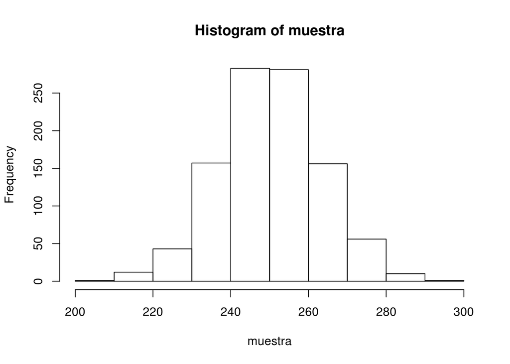

```r
#Media
m <- 250
#Desviación típica
sd <- 13
#Números
n <- 1000

#Generación de la muestra
muestra <- rnorm(n, m, sd)

#Histograma
hist(muestra)
```

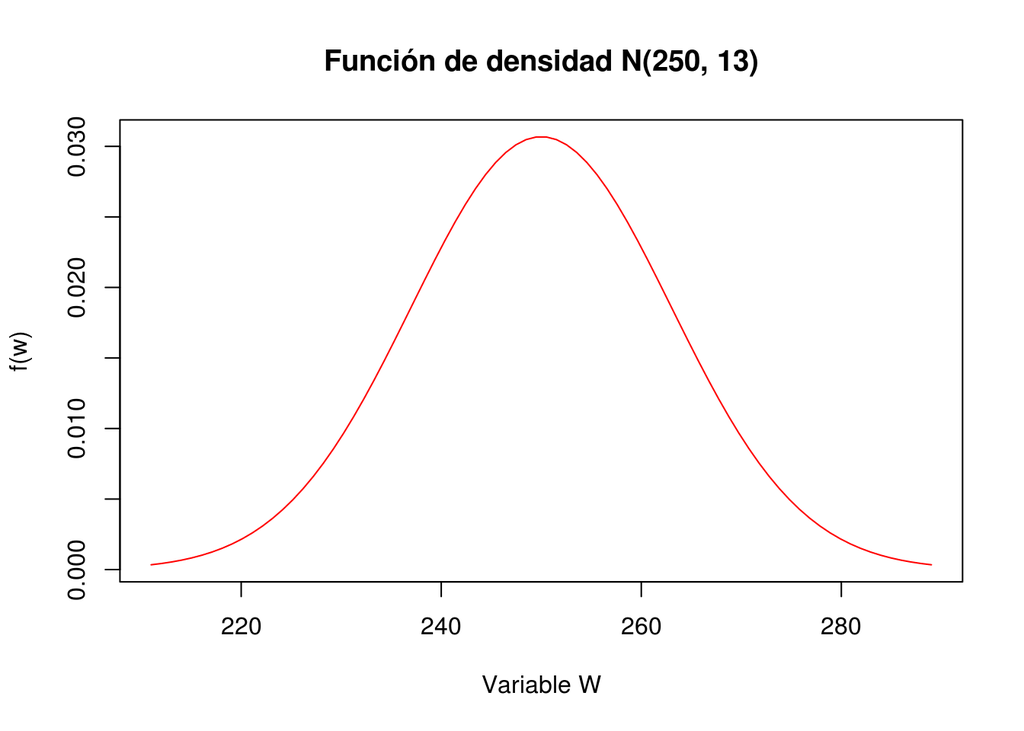

```r
#Función de densidad
li<-m-3*sd
ls<-m+3*sd

# Número de puntos a dibujar
npuntos<-ls-li
x<-seq(li, ls, length.out=npuntos)
# Valores de y
y<-dnorm(x, m, sd)

# Dibujar f(w)
fw<-plot(x, y, type="l", xlab="Variable W", ylab="f(w)", main="Función de densidad N(250, 13)", col="red")
```

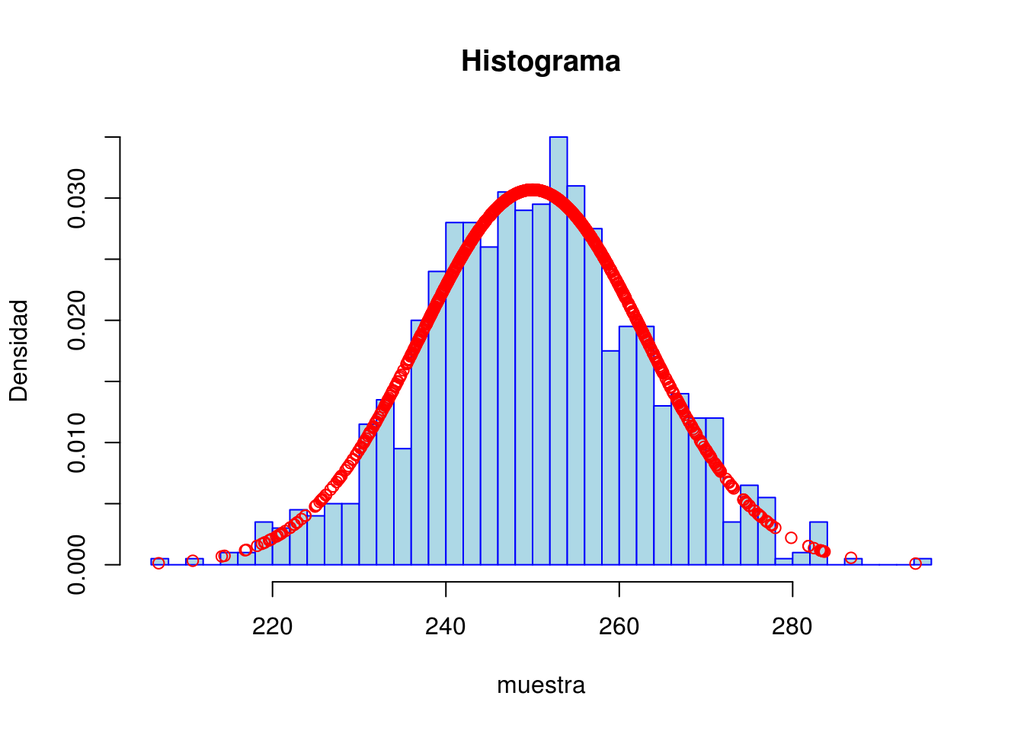

```r
#Representamos histograma y función de densidad en la misma gráfica
#Intervalos
int<-round(sqrt(n), 0)

# Histograma de la muestra
hist(muestra, breaks=int, freq=F, xlab="muestra", ylab="Densidad",     main="Histograma", col="lightblue", border="blue")
# Incluimos f(w)
lines(muestra, dnorm(muestra,m,sd), type="p", col="red")
```

## 4. CONTRASTES DE HIPÓTESIS E INTERVALOS DE CONFIANZA

### 1. Cargar el fichero Temperatura.RData.

```r
load('./Datos/Temperatura.RData')
str(Temper)
```

```
## 'data.frame':    156 obs. of  2 variables:
##  $ Estacion: Factor w/ 2 levels "A","B": 1 1 2 2 1 1 1 2 2 1 ...
##  $ Temper  : num  23.1 22.1 20.2 24.6 23.9 ...
```

### 2. Crear dos nuevas variables, temp.A y temp.B, que contengan las temperaturas de las estaciones A y B, respectivamente.

```r
temp.A <- Temper[Temper$Estacion == "A",]$Temper
temp.B <- Temper[Temper$Estacion == "B",]$Temper
```

### 3. Da un intervalo de confianza para la temperatura media diaria de la estación A, al 95%, y a partir de éste indica si se puede admitir, y por qué, que la temperatura media diaria en dicha estación sea de 19ºC, con ese mismo nivel de confianza.

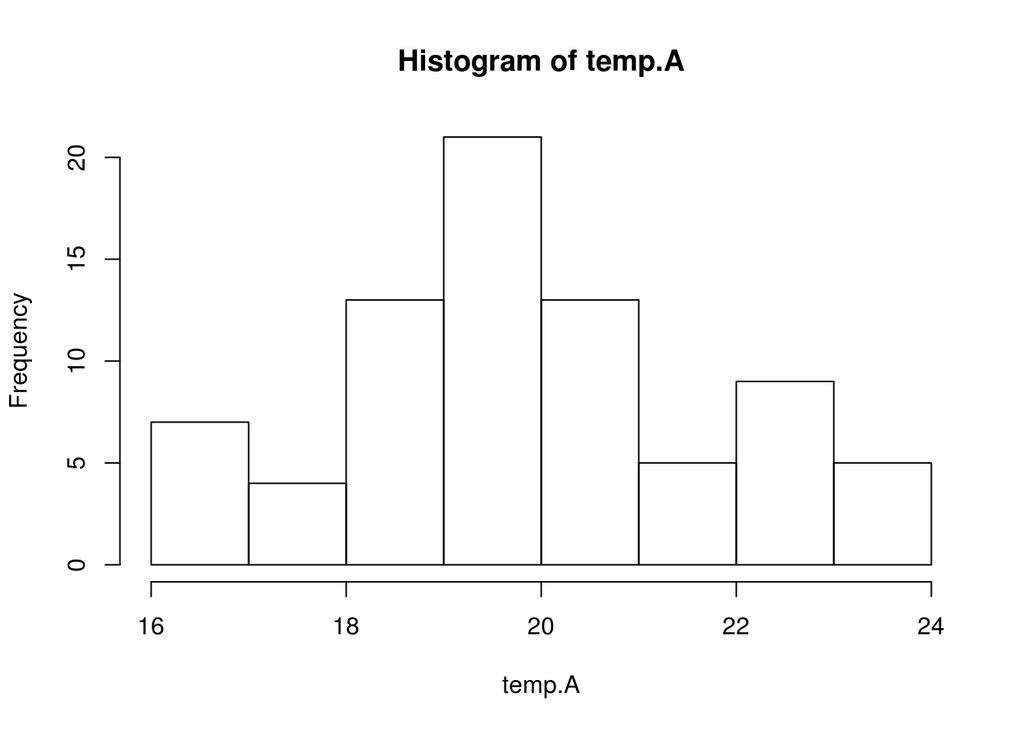

```r
hist(temp.A)
```

```r
summary(temp.A)
```

```
##    Min. 1st Qu.  Median    Mean 3rd Qu.    Max.
##   16.21   18.50   19.70   19.82   20.95   23.87
```

```r
IC <- t.test(temp.A, alternative = "two.sided", conf.level = 0.95)
IC
```

```
##
##  One Sample t-test
##
## data:  temp.A
## t = 93.167, df = 76, p-value < 2.2e-16
## alternative hypothesis: true mean is not equal to 0
## 95 percent confidence interval:
##  19.39401 20.24131
## sample estimates:
## mean of x
##  19.81766
```

El intervalo de confianza al 95% es [19.39401, 20.24131].

Por lo tanto, no se puede admitir que 19ºC sea la temperatura media diaria de la estación A si se desea un intervalo de confianza del 95%

### 4. Plantea un test de hipótesis que refleje la pregunta del apartado anterior y resuélvelo sin usar el intervalo de confianza (riesgo de 1ª especie 5%)

El contraste que se plantea es:

- H0: mA = 19
- H1: mA <> 19

Como se pide explícitamente contrastar si la media puede ser 19ºC, ahora sí hay que especificar el valor del argumento mu = 19.

```r
Contraste <- t.test(temp.A, alternative = "two.sided", mu = 19, conf.level = 0.95)
Contraste
```

```
##
##  One Sample t-test
##
## data:  temp.A
## t = 3.844, df = 76, p-value = 0.0002496
## alternative hypothesis: true mean is not equal to 19
## 95 percent confidence interval:
##  19.39401 20.24131
## sample estimates:
## mean of x
##  19.81766
```

El p-valor es 0.0002496, y es mucho menor que 0,05, por lo que podemos afirmar que la temperatura media en la estación A no estaría en 19ºC con un riesgo de 1ª especie del 5%.

### 5. Determina si puede admitirse, con un riesgo de primera especie de 1%, que la temperatura media diaria es la misma en las dos estaciones.

Plantea previamente el correspondiente contraste de hipótesis.

En este caso vamos a comparar la temperatura en la estación A (temp.A) y la temperatura en la estación B (temp.B).

Mediante el test vamos a tratar de determinar si puede admitirse, con un riesgo de primera especie de 1% (alfa), que la temperatura media es la misma en la estación A y en la B.

El contrsaste o test de hipótesis que se plantea es:

- H0: mA = mB
- H1: mA <> mB

En primer lugar vamos a determinar si las varianzas de la temp media en ambas estaciones son iguales con el var.test() (Test F).

```r
var.temp <- var.test(temp.A, temp.B, ratio = 1, alternative = "two.sided", conf.level = 0.99)
var.temp
```

```
##
##  F test to compare two variances
##
## data:  temp.A and temp.B
## F = 1.0978, num df = 76, denom df = 78, p-value = 0.6825
## alternative hypothesis: true ratio of variances is not equal to 1
## 99 percent confidence interval:
##  0.6071355 1.9889245
## sample estimates:
## ratio of variances
##             1.0978
```

El p-valor es 0.6825, y es mayor que 0,1, por lo que podemos afirmar que la varianza de la temperatura en la estación A no difere de la del B, con un riesgo de 1ª especia del 1%.

Así pues, ahora podemos volver sobre la comparación de medias (temp) asumiendo que las varianzas de las temperaturas en las estaciones A y B son iguales.

Por otra parte, tal y como se ha planteado el contraste inicialmente, consideramos que el procedimiento estadístico empleado es bilateral, por lo que incorporamos el argumento alternative = “two.sided”.

Por último, la hipótesis a contrastar (mA = mB) representa que las medias de la temperatura en la estación A y en la estación B pueden considerarse iguales.

Esto esm la hipótesis nula implícita es que la diferencia de las medias de la temperatura es cero (mA - mB = 0). Por tanto, el valor del argumento mu, que representa la diferencia de medias que se contrasta en la H0, debe ser mu = 0. Ya tenemos toda la información necesaria para realizar el contraste ejecutando el test.t:

```r
test.temperaturaAB <- t.test(temp.A, temp.B, alternative = "two.sided", mu = 0, paired = F, var.equal = T, conf.level = 0.99)
test.temperaturaAB
```

```
##
##  Two Sample t-test
##
## data:  temp.A and temp.B
## t = -0.64116, df = 154, p-value = 0.5224
## alternative hypothesis: true difference in means is not equal to 0
## 99 percent confidence interval:
##  -0.9490744  0.5745257
## sample estimates:
## mean of x mean of y
##  19.81766  20.00494
```

El p-valor es 0.5224, y es mayor que 0,1 (mayor que 0.5, de hecho), por lo que podemos afirmar que la temperatura media en la estación A no difiere significativamente de la temp media de la B, con un riesgo de 1ª especie del 1%.

### 6. Obtén un intervalo de confianza (99%) para la diferencia de temperaturas entre estaciones.

Este intervalo de confianza se puede obtener a raíz del resultado obtenido en el apartado anterior. Donde obtuvimos:

99 percent confidence interval: -0.9490744 0.5745257

Así pues, el intervalo de confianza al 99% es el siguiente: [-0.9490744, 0.5745257]. Es importante destacar que este rango no representa un intervalo para las temperaturas medias, sino para la diferencia de las medias entre la temperatura en la estación A y la temp en la estación B.

#### ¿Aporta alguna información adicional al resultado obtenido en el apartado anterior?

Para saber si las medias de temperatura entre ambas estaciones pueden considerarse iguales, bastaría sólo con el contraste. Sin embargo, con el intervalo de confianza podemos determinar también el umbral a partir del cuál podemos considerar ambas medias significativamente iguales o no. De este modo el intervalo [-0.9490744, 0.5745257] nos indica que cualquier hipótesis nula que planteáramos donde las diferencias de las medias difirieran en -0.9490744 (si mA < mB) o 0.5745257 (si mA > mB) sería aceptada también.

Si lo que queremos es simplemente determinar si podemos admitir que hay o no diferencias en cuanto a la media de la temperatura en las estaciones A y B, el cálculo del intervalo de confianza no aportaría nada, sería suficiente realizar el test propiamente dicho y evaluar el p valor. Ahora bien, dar un intervalo de confianza es más informativo que aceptar o rechazar una hipótesis concreta para un nivel de confianza determinado. En este caso, el intervalo [-0.9490744, 0.5745257] nos indica que cualquier hipótesis nula que planteáramos de modo que las medias de las temperaturas difirieran realmente en -0.9490744 (si mA < mB) o 0.5745257 (si mA > mB) sería aceptada también.

Para responder a esta pregunta podemos construir un IC para la diferencia de proporciones de temperaturas en ambas estaciones.

Creamos matriz de contingencia

```r
fallo.A <- 5
fallo.B <- 7

exito.A <- length(temp.A) - fallo.A
exito.B <- length(temp.B) - fallo.B

tabla_cont <- matrix(c(fallo.A,fallo.B, exito.A, exito.B), 2, 2)
tabla_cont
```

```
##      [,1] [,2]
## [1,]    5   72
## [2,]    7   72
```

Para un nivel de confianza del 90%, se tiene que el nivel de significación alfa es 0,1. Suponemos también que el contraste es bilateral. Realizamos el contraste:

```r
prop.test(tabla_cont, alternative = "two.sided", conf.level = 0.9)
```

```
##
##  2-sample test for equality of proportions with continuity
##  correction
##
## data:  tabla_cont
## X-squared = 0.064647, df = 1, p-value = 0.7993
## alternative hypothesis: two.sided
## 90 percent confidence interval:
##  -0.10648910  0.05914404
## sample estimates:
##     prop 1     prop 2
## 0.06493506 0.08860759
```

Como p-valor es 0.7993, y es mayor que 0,1, podemos afirmar que la proporción de fallos en la estación A no difiere significativamente de los de la estación B, con un riesgo de 1ª especie del 10%.

También llegamos a la misma conclusión observando que el 0 (que implicaría una diferencia nula entre ambas proporciones) se encuentra también en el intervalo de confianza para la diferencia de proporciones obtenido: [-0.10648910 0.05914404].